# Forest Fire Analysis

Eric, Sagan, and Gaurang

2022-12-14

## Background

*Format*: A data frame with 517 observations on the following 13 variables.

- X - West to east coordinates for the site (1=farthest west to 9= farthest east)
- Y - North to south coordinates for the site (1=farthest north to 9=farthest south)
- Month - Month of the year (Jan to Dec)
- Day - Day of the week (Sun to Sat)
- FFMC - Fine fuel moisture code
- DMC - Duff moisture code
- DC - Drought code
- ISI - Initial spread index
- Temp - Outside temperature (in Celsius)
- RH - Relative humidity (in %)
- Wind - Wind speed (in km/h)
- Rain - Rain in past 30 minutes (in mm/sq-m)
- Area - Total burned area (in hectares)

*Detail came with the data sets:*  
Data were recorded for fires in the Montesinho natural park in Portugal between January 2000 and December 2003. A map of the park is divided into 9x9 grid sections (given by the x,y-coordinates in the first two columns of the data set). There are four components of a Fire Weather Index that rate how weather conditions might increase fire danger. FFMC. DMC, and DC reflect various measures of moisture content, while the ISI score indicated how fast a fire might spread (for example, by wind). For all four measures larger values are associated with more fire danger. Fires that are less than 100 square meters in size (0.01 hectares) are recorded as Area=0.

*FWI System*

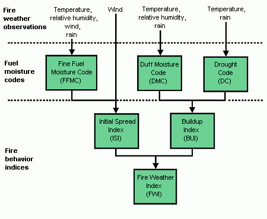

Figure 1 demonstrate the Canadian forest fire weather index system, also known as FWI. The picture explains the relationship between each fire weather observations connect to each of the moisture code and how each variable contribute to the fire behavior indices.

*Elaboration on each of the Fuel Moisture Code*

FFMC - Represent the fuel moisture content of forest litter fuels under the shade of a forest canopy, ranging from 0 to 101. The higher the FFMC, the higher risk of having a forest fire.

DMC - Represents the moisture content of decomposed organic material underneath the litter. Ranging from 0 to infinite.

DC - Represents the level of drying in the soil. Ranging from 0 to infinite.

ISI - Higher ISI means more dangerous in the level of fire.

## Research questions

1. What’s the most significant predictor (FFMC, DMC, DC) for the total burned area?
   - $H_{0}$: None of the predictors are significant.
   - $H_{A}$: All, or some of the predictors are significant.
2. How does this data set in the region of the world compare to other regions during this time period?

## Discussion

Table 1: Summary table

|  | vars | n | mean | sd | median | trimmed | mad | min | max | range | skew | kurtosis | se |
| --- | --- | --- | --- | --- | --- | --- | --- | --- | --- | --- | --- | --- | --- |
| X | 1 | 270 | 4.81 | 2.38 | 5.0 | 4.83 | 2.97 | 1.00 | 9.0 | 8.00 | -0.05 | -1.22 | 0.15 |
| Y | 2 | 270 | 4.37 | 1.17 | 4.0 | 4.35 | 1.48 | 2.00 | 9.0 | 7.00 | 0.55 | 1.79 | 0.07 |
| Month* | 3 | 270 | 5.79 | 3.57 | 5.0 | 5.75 | 4.45 | 1.00 | 10.0 | 9.00 | 0.11 | -1.76 | 0.22 |
| Day* | 4 | 270 | 3.81 | 1.97 | 4.0 | 3.77 | 2.97 | 1.00 | 7.0 | 6.00 | 0.12 | -1.18 | 0.12 |
| FFMC | 5 | 270 | 91.03 | 3.71 | 91.7 | 91.56 | 2.00 | 63.50 | 96.2 | 32.70 | -2.68 | 12.76 | 0.23 |
| DMC | 6 | 270 | 114.71 | 61.79 | 111.7 | 111.29 | 43.88 | 3.20 | 291.3 | 288.10 | 0.53 | 0.45 | 3.76 |
| DC | 7 | 270 | 570.87 | 229.98 | 665.6 | 605.82 | 117.57 | 15.30 | 860.6 | 845.30 | -1.26 | 0.37 | 14.00 |
| ISI | 8 | 270 | 9.18 | 4.15 | 8.4 | 8.93 | 3.04 | 0.80 | 22.7 | 21.90 | 0.66 | 0.32 | 0.25 |
| Temp | 9 | 270 | 19.31 | 6.18 | 20.1 | 19.68 | 5.34 | 2.20 | 33.3 | 31.10 | -0.52 | 0.16 | 0.38 |
| RH | 10 | 270 | 43.73 | 15.08 | 41.0 | 42.39 | 14.83 | 15.00 | 96.0 | 81.00 | 0.76 | 0.16 | 0.92 |
| Wind | 11 | 270 | 4.11 | 1.88 | 4.0 | 3.95 | 1.93 | 0.40 | 9.4 | 9.00 | 0.69 | 0.18 | 0.11 |
| Rain | 12 | 270 | 0.03 | 0.40 | 0.0 | 0.00 | 0.00 | 0.00 | 6.4 | 6.40 | 15.30 | 239.76 | 0.02 |
| Area | 13 | 270 | 2.13 | 1.26 | 2.0 | 2.02 | 1.25 | 0.09 | 7.0 | 6.91 | 0.88 | 0.73 | 0.08 |